# Inhale, Exhale, Analyze: Using Linear Mixed Models to Predict Airway Resistance and Reactance Measures

UWF STA 6257 Capstone Project on Linear Mixed Models (LMMs)

Joshua J. Cook, M.S., ACRP-PM, CCRC

jcook0312@outlook.com

Syed Ahzaz H. Shah, B.S.

shs17@students.uwf.edu

Jacob Hernandez, B.S.

jacob.hernandez0830@gmail.com

Sara Basili, M.S.

saraelizabethbasili@gmail.com

April 16, 2024

# Introduction to Linear Mixed Models (LMMs)

## Introduction

### Understanding Linear Mixed-Effects Models (LMMs)

- **Linear mixed-effects models** are advanced statistical tools designed to handle complex data structures.
- These models are essential when dealing with **hierarchical organization**, **repeated measures**, and **random effects** in datasets.
- LMMs are particularly useful when traditional **ANOVA or regression assumptions**—like independence of observations, homoscedasticity, and normality of residuals—**are not met.**

## Software Tools and Resources for LMMs

### Tools for Implementing LMMs

- The development and use of LMMs are supported by several software packages and programming languages.
- Key resources include the `lme4` package in **R**, detailed by Bates et al. (2015), which simplifies the fitting of mixed models, especially those with crossed random effects.
- For Python users, `Pymer4` developed by Jolly (2018) integrates **Python** with R’s lme4 package, broadening accessibility to these advanced methods.

## Applications of LMMs Across Disciplines

### Broad Applications of LMMs

- LMMs find **diverse applications** across various scientific domains, addressing unique analytical challenges.
  - In healthcare, LMMs model pandemic-related mortality changes (Verbeeck et al., 2023) and analyze longitudinal data in clinical trials (Touraine et al., 2023).
  - In ecology, studies by Harrison et al. (2018) and Bolker et al. (2009) discuss their use in analyzing complex ecological data.
  - In psychology and neuroscience, LMMs tackle the complexities of repeated measures and nested data structures (Magezi, 2015; Aarts et al., 2015).

# Methods - Mathematical Foundations

## Linear Algebra

### Foundations

LMMs leverage **linear algebra** and in our case, we are explaining the mathematical concepts for a **two-level longitudinal random intercepts model.** Index *i* is used to denote the participant and index *t* is used to denote the different time points of the observation

$$Y=X\beta + Zu+ \epsilon$$

Equation 1: the base linear mixed model.

- **Y** is the response vector. Shape N x 1 where N is the number of the number of repeated measures
- **X** is the design matrix for fixed effects. Shape N x p where p is the number of regression coefficients
- **β** is the vector of regression coefficients. Shape P x 1
- **Z** is the design matrix for random effects. Shape N x J where J number of subjects
- *u* is the vector of random effects. Shape J x 1 vector
- **ϵ i**s the vector of residual errors. Shape N x 1 vector

## Assumptions

1. The relationship between the **predictors and response** variable is assumed to be **linear**, within each level of random effects.
2. **Random effects** **(*u*)** are assumed to follow a **normal distribution** with mean zero and variance-covariance matrix G.

   $\gamma \sim N(0,G)$
3. **Residual errors (ϵ )** are assumed to follow a **normal distribution** with mean zero and variance-covariance matrix R.

   $\epsilon \sim N(0,R)$
4. **Random effects (*u*) and residual errors (ϵ ) are assumed to be independent.**
5. **Homoscedasticity** is assumed for the residuals across all levels of the independent variables.

## Implementation in R

- Data is loaded from a CSV file using the read.csv function
- Fitting Data to LMMs
  - The **lme()** function from the `nlme` package has parameters to specify random effects structure and estimation method.
  - **lmer()** function from the `lme4` package has similar syntax to the lme() function but differs in how it handles random effects specifications
- Hypothesis Testing
  - Evaluated using **F-tests, Likelihood ratio test, and Shapiro-Wilks tests**

# The Capstone Project Data

## Dataset Overview

- Key attributes and measurements in the dataset.
- Categorical and numerical variables.
- Presence of **missing values**, espsecially in the `Fres_PP` variable.

## Why Linear Mixed Models (LMMs)?

- Suitability of LMMs for the dataset.
- **Multiple observations over time** for the same participants.
- Handling **unbalanced groups**, as observed in participant dropout over time.

## EDA - Categorical Variables

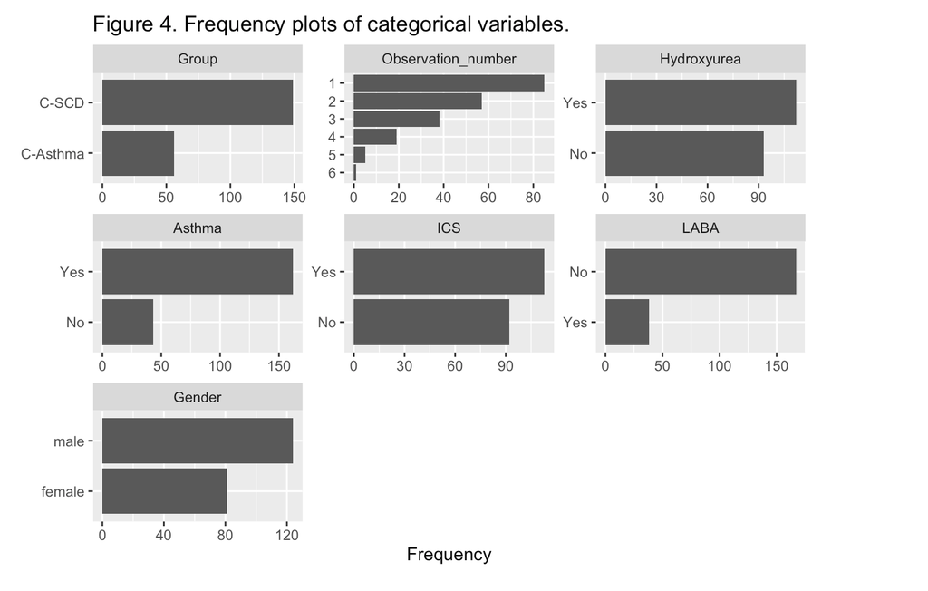

## EDA - Numerical Variables

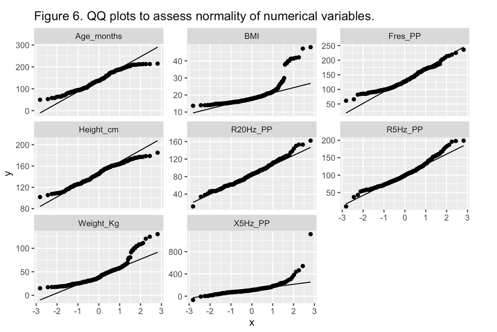

## Outlier Detection and Summary Statistics

- Presence of **outliers** in variables and their implications.

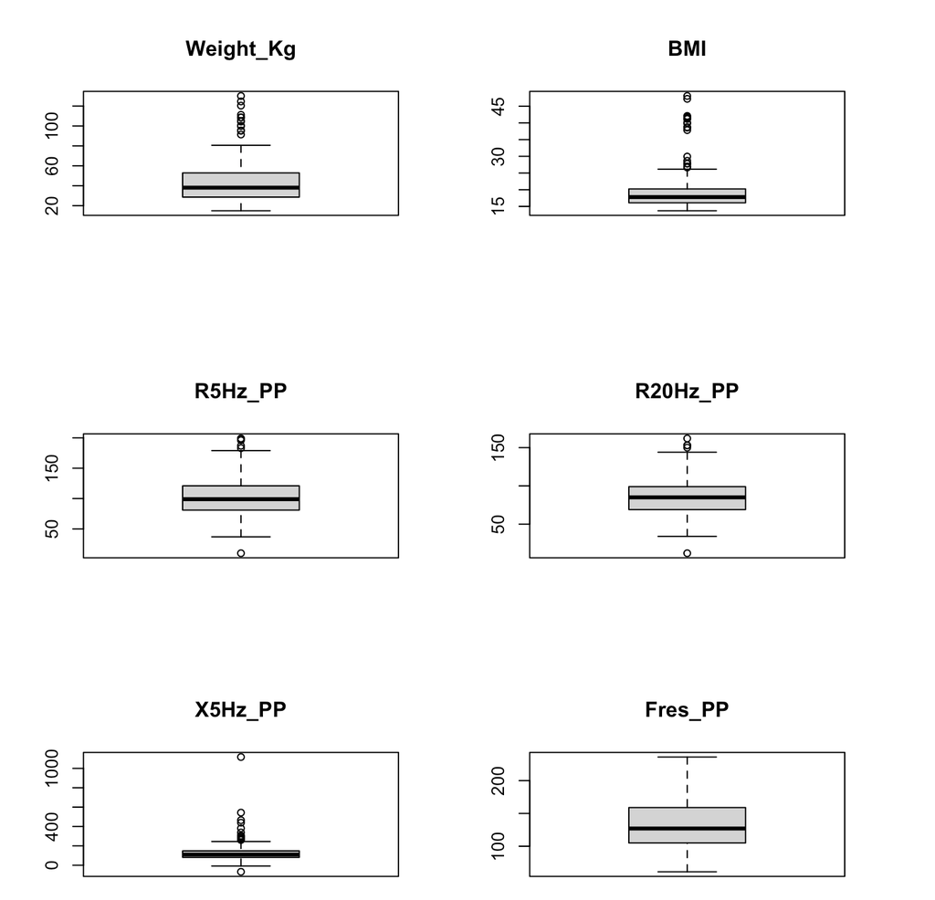

## Participant Dropout Analysis

- **Significance of participant dropout over time.**
- Ability of LMMs to **handle unbalanced groups**

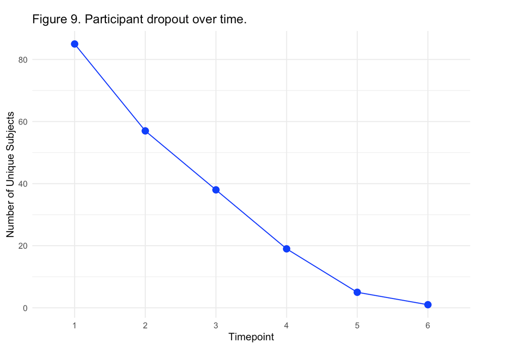

# Analysis & Results

## The Initial Model

### One Random Effect

In this dataset:

- Measures of airway resistance and reactance are the **variables of interest**: `R5Hz_PP`, `R20Hz_PP`, `X5Hz_PP`, `Fres_PP`.
- Controlled variables are present such as `Group`, `Age`, `Weight`, `Height`, and other Co-morbidities. These are the **fixed effects.**
- Random variability may exist between individual observations which are nested in each subject. These represent the **random effects.** In the **initial model**, `Subject_ID` was treated as the sole *random effect*.

## The Initial Model

### One Random Effect

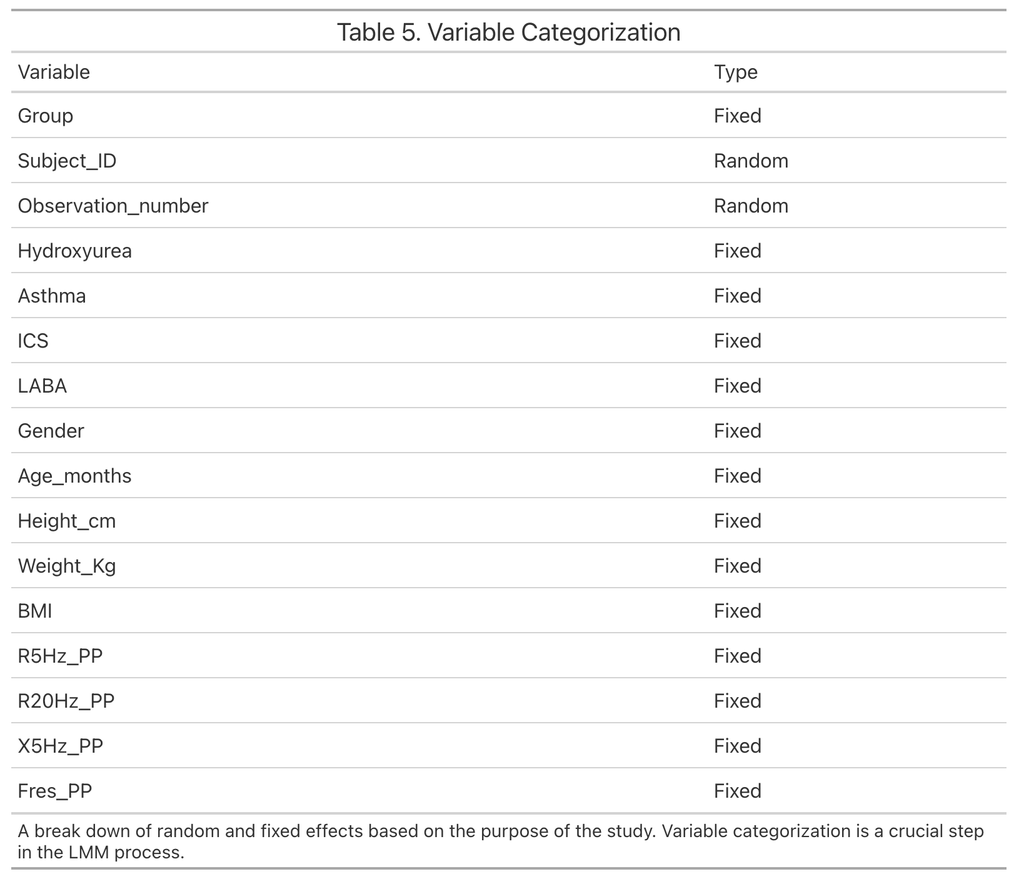

## The Initial Model

### One Random Effect

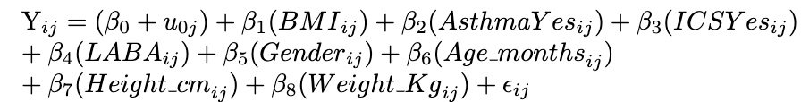

Equation 2. The initial LMM.

## Implementation

```r
#lme()

# Fit models using a tidy and clear approach
model_lme <- lme(
  fixed = cbind(R5Hz_PP, R20Hz_PP, X5Hz_PP, Fres_PP) ~ BMI + Asthma + ICS + LABA + Gender + Age_months + Height_cm + Weight_Kg,
  random = list(Subject_ID = pdIdent(~1)),
  data = x_clean,
  method = "REML"
)

#lmer()

model_lmer <- lmer(
  formula = R5Hz_PP + R20Hz_PP + X5Hz_PP + Fres_PP ~ BMI + Asthma + ICS + LABA + Gender + Age_months + Height_cm + Weight_Kg + (1 | Subject_ID),
  data = x_clean
)
```

## Evaluation

- **Akaike Information Criterion (AIC)** - indicator of model fit without unnecessary complexity.
  - AIC for lme = 1898.95 **(selected as initial model)**
  - AIC for lmer = 2517.37
- Assumptions Check - **normality**.

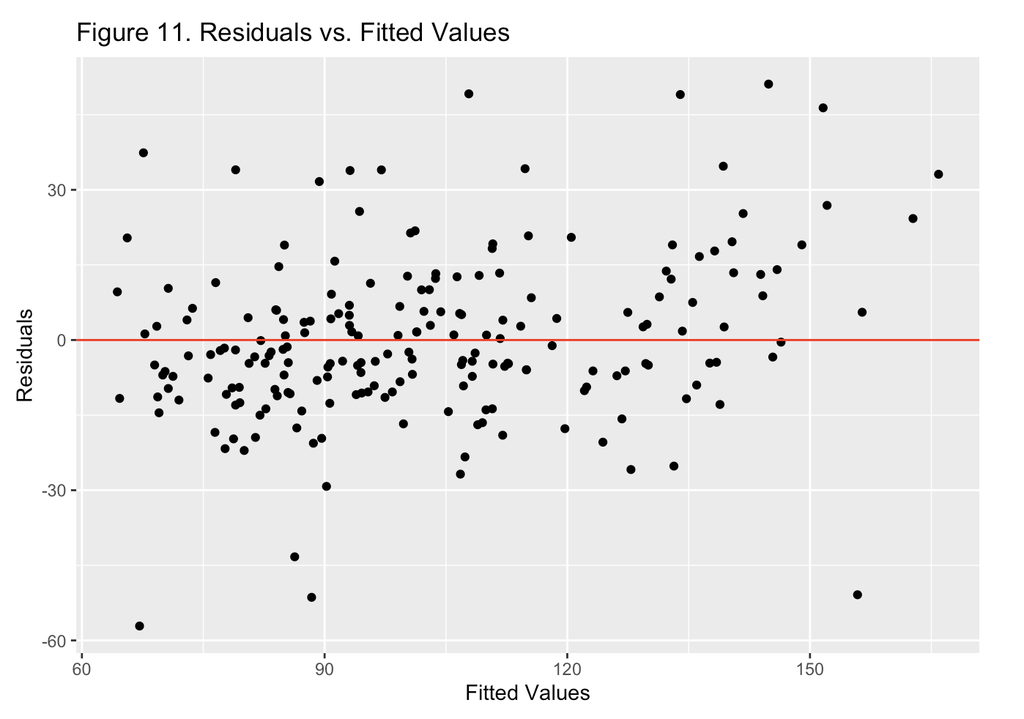

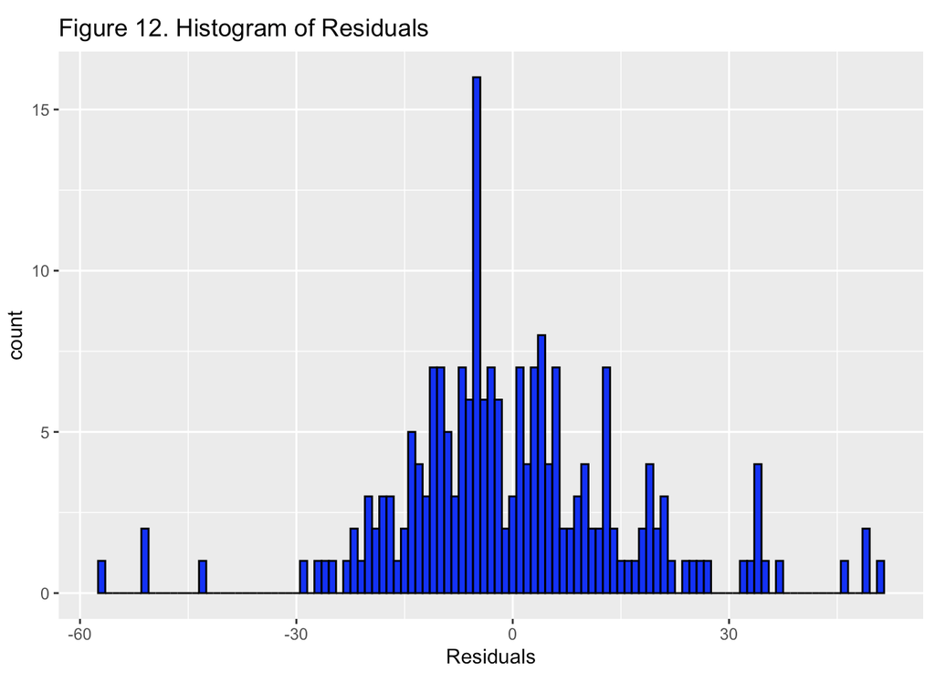

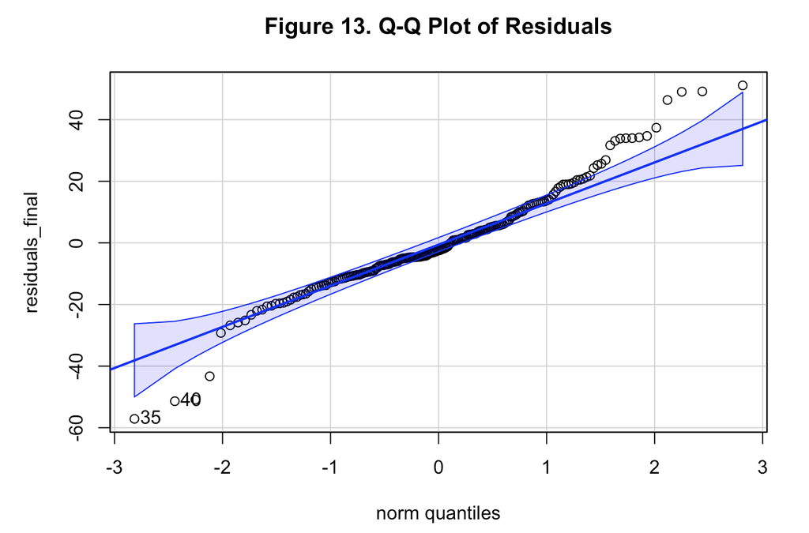

**Finding:** the residuals **were not** normally distributed, so this model does not satisfy the assumptions of LMMs.

## The Imputed Model

### Satisfying Assumptions

- Upon further inspection, **outliers were present** in most variables.
- To improve model performance, these **outliers were imputed using the threshold values *(i.e., winsorization).***
- Confirmation of outlier removal was completed using **boxplots**.
- All metrics were then **reevaluated**.

## Evaluation

**AIC** for lme = 1790.91 **(better!)**

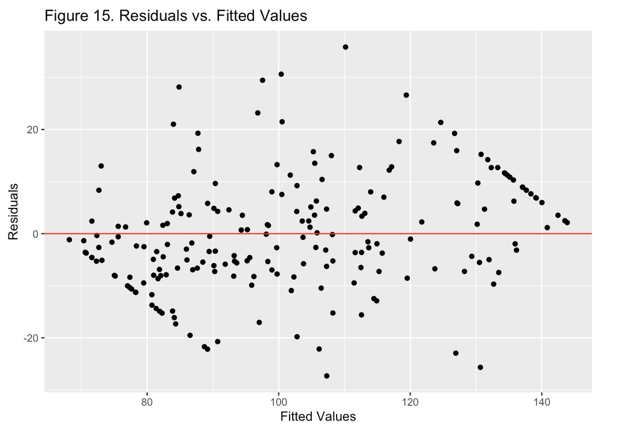

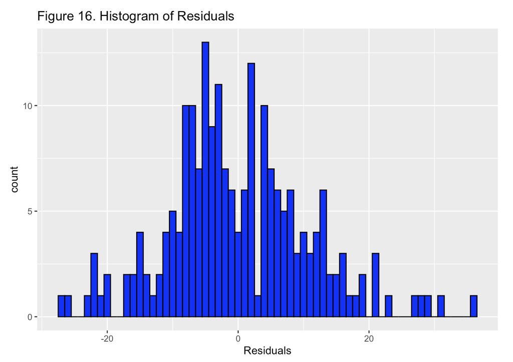

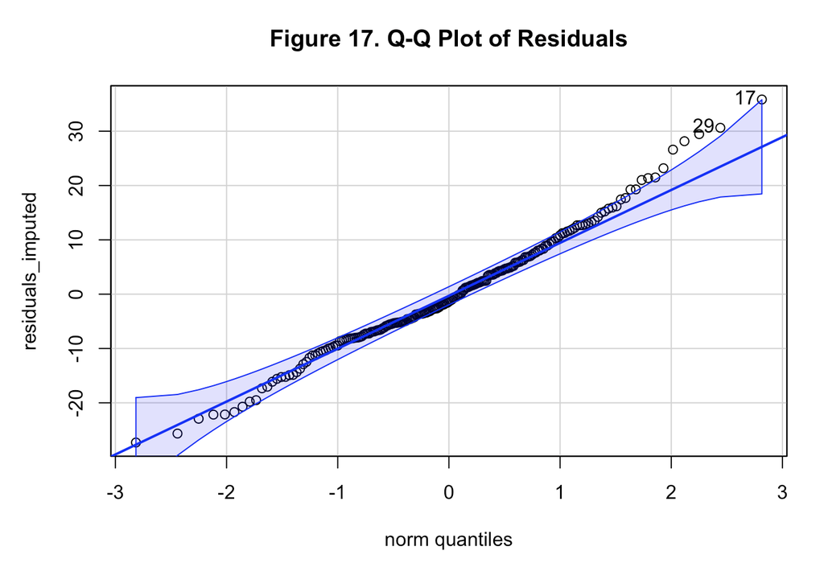

**Finding:** the residuals were normally distributed, so this **model does satisfies the assumptions of LMMs.**

## The Final Model

### Two Random Effects and Final Fixed Effect

This was a **longitudinal study** involving multiple observations for each subject over time, and subjects are grouped into **two categories** (children with sickle cell disease and African-American children with asthma).

Thus, in this final model:

- we modeled **`Group`** as a *fixed effect* since we were interested in the effect of the group itself on the outcome.
- **`Subject_ID`** should be a *random effect* to account for the repeated measures within subjects.
- **`Observation_number`** was included as a *random slope* within **`Subject_ID`** (i.e., nested within Subject_ID).
- The **same visualizations and tests** were completed to assess the LMM assumptions.

## The Final Model

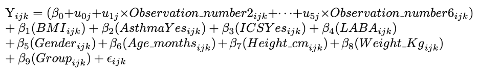

Equation 3. The final LMM.

## Implementation

```r
model_lme_imputed_final <- lme(fixed = cbind(R5Hz_PP, R20Hz_PP, X5Hz_PP, Fres_PP) ~ BMI + Asthma + ICS + LABA + Gender + Age_months + Height_cm + Weight_Kg + Group,
                         data = x_clean_imputed,
                         random = list(Subject_ID = pdIdent(~1 + Observation_number)),
                         method = "REML")
```

## Evaluation

- **AIC** for lme = 1801.60 (better than initial, but worse than imputed?)

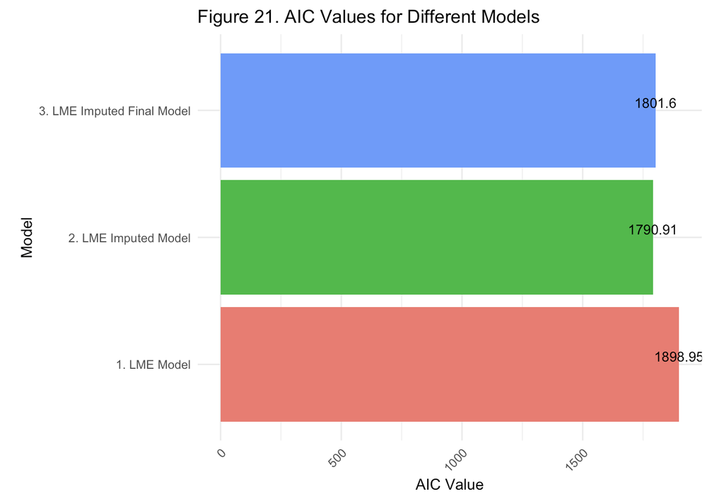

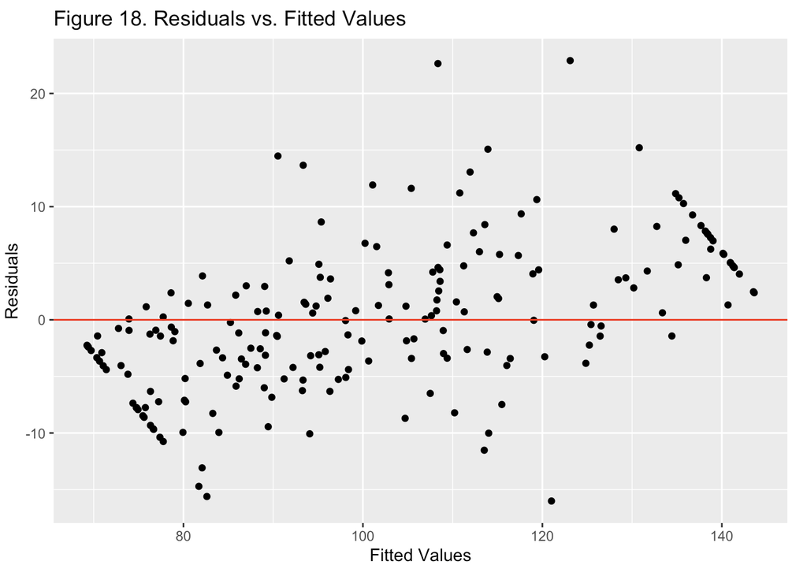

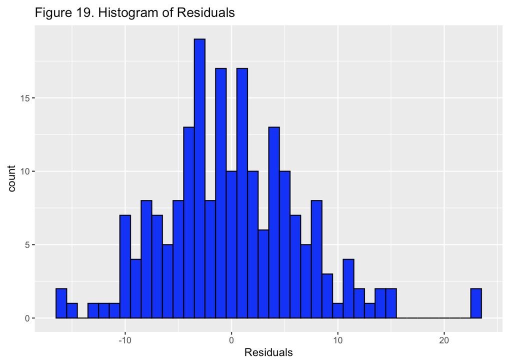

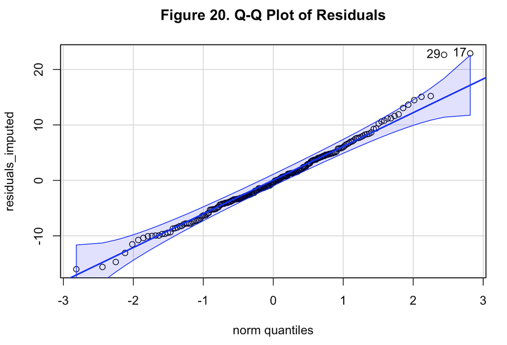

**Findings:**

- The residuals were normally distributed, so this **model does satisfies the assumptions of LMMs.**
- The AIC penalizes model complexity to avoid overfitting, suggesting that the added effects of Group and Observation_number **may not be sufficiently increasing model accuracy compared to complexity.**
- However, these effects may still be relevant given the research goal of the project despite the slight increase in AIC, **and thus will be left in the final model.**

# Conclusion

## Overview of Model Evaluations

- In our analysis, we compared three Linear Mixed Models: the **base model**, the **model with imputed values**, and the **final adjusted model**, to predict airway resistance and reactance effectively.
- We focused on **Mean Squared Error (MSE)** and **Mean Absolute Error (MAE)** to assess model performance.

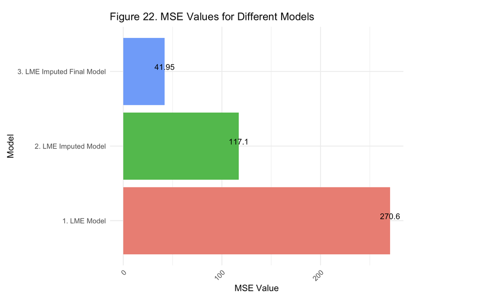

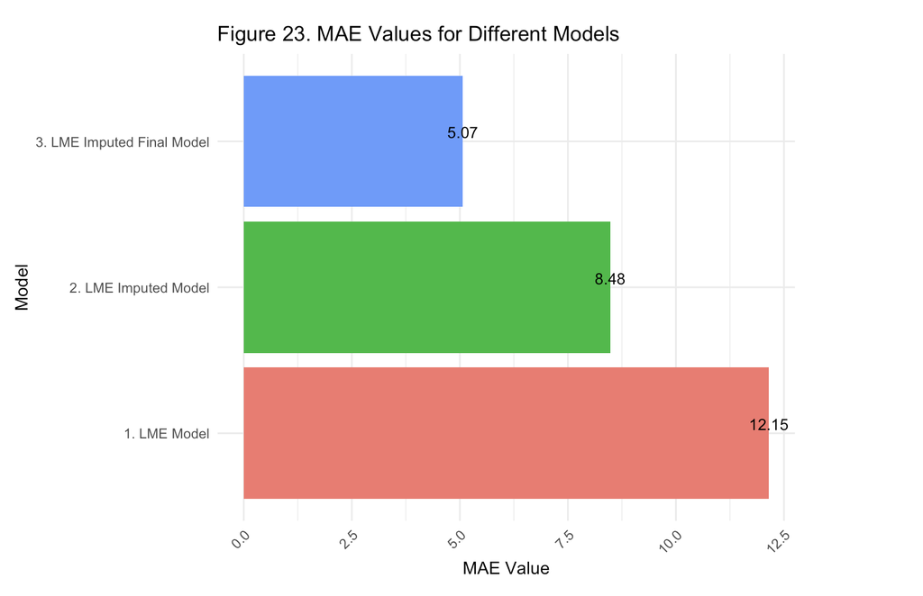

- **Findings:** The **final imputed model** achieved the lowest MSE and MAE, indicating superior performance over the other models.

## Sample Predictions vs. Actual Data

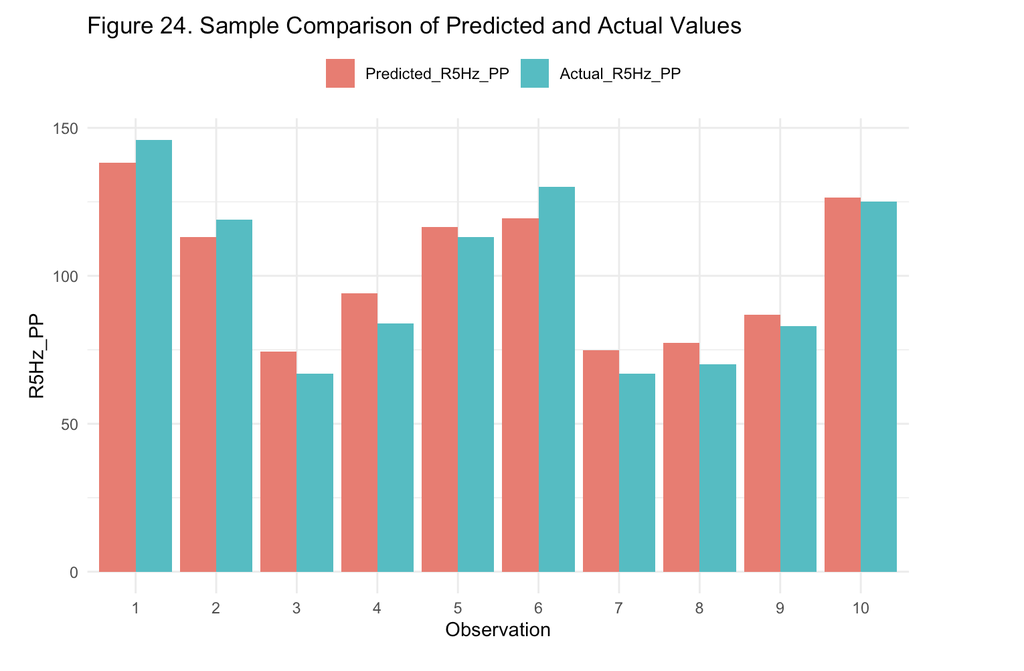

- Figure 24 illustrates a side-by-side comparison of the **predicted versus actual values** for `R5Hz_PP`, a measure of airway resistance and reactance, for **10 random subjects.**
- The **close alignment** between predicted and actual values **represents a low residual error,** confirming the **model’s high accuracy** in predicting `R5Hz_PP`.

## Conclusion

- Our analysis demonstrates that **linear mixed models are exceptionally versatile and can effectively handle complex datasets with multiple layers of correlation and missing data**, incorporating both fixed and random effects seamlessly.
- **Our final model accurately predicts airway resistance and reactance** given demographic and co-morbidity data, which could aid in better understanding and managing respiratory functions in children with conditions such as Sickle Cell Disease and asthma.

## Acknowledgements

The authors thank **Dr. Achraf Cohen**, for his ongoing mentorship and support.

Questions are welcome and encouraged!

[figure not shown]